# Distributions homework

# MVP

```r
library(tidyverse)
library(janitor)
```

*Question 1.* Load the data, clean_names() and explore it.

*Answer 1.*

```r
phones_data <- read_csv("data/20190928-items.csv") %>%
  clean_names()
glimpse(phones_data)
```

```
Rows: 792
Columns: 9
$ asin          <chr> "B0000SX2UC", "B0009N5L7K", "B000SKTZ0S", "B00198M12M", "B001AO4OUC", "B001DCJAJG", "…
$ brand         <chr> "Nokia", "Motorola", "Motorola", "Nokia", "Motorola", "Motorola", "Sony", "Nokia", "N…
$ title         <chr> "Dual-Band / Tri-Mode Sprint PCS Phone w/ Voice Activated Dialing & Bright White Back…
$ url           <chr> "https://www.amazon.com/Dual-Band-Tri-Mode-Activated-Dialing-Backlit/dp/B0000SX2UC", …
$ image         <chr> "https://m.media-amazon.com/images/I/2143EBQ210L._AC_UY218_SEARCH213888_FMwebp_QL75_.…
$ rating        <dbl> 3.0, 2.9, 2.6, 2.4, 3.3, 3.2, 2.0, 2.7, 3.2, 3.5, 2.9, 2.9, 2.8, 2.8, 2.6, 3.2, 2.9, …
$ review_url    <chr> "https://www.amazon.com/product-reviews/B0000SX2UC", "https://www.amazon.com/product-…
$ total_reviews <dbl> 14, 7, 22, 5, 21, 12, 1, 3, 8, 133, 2, 18, 201, 76, 131, 66, 3, 15, 102, 146, 348, 56…
$ prices        <chr> NA, "$49.95", NA, NA, NA, NA, "$78.99", NA, "$99.99", "$59.89", "$99.95", "$149.95", …
```

*Question 2.* Find the brand with the highest numbers of phones in the dataset.

*Answer 2.*

```r
phones_data %>%
  group_by(brand) %>%
  summarise(n_phones = n()) %>%
  slice_max(n_phones)
```

| brand | n_phones |
| --- | --- |
| Samsung | 397 |

```r
NA
```

Samsung is the brand with the highest number of phones (397) in the dataset.

*Question 3.* For your top brand, plot the distribution of phone ratings as a probability density, overlaying a fitted normal distribution. Do you think the normal distribution provides a good model of these ratings?

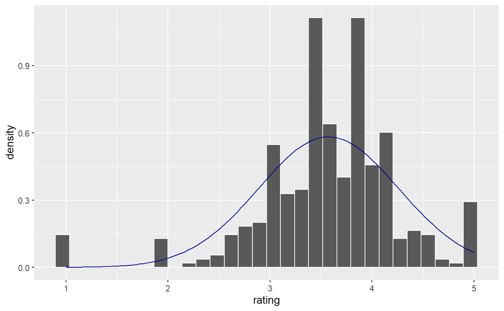

*Question 4.* We can be more quantitative in comparing the distribution of top brand ratings with a normal distribution. You calculated the mean() and sd() of your distribution in an earlier question. Use these values to calculate the proportions of ratings within one-, two- and three standard deviations of the mean. Compare these proportions with those you expect for a normal distribution.

| prop_within_1sd |
| --- |
| 0.7934509 |

For a normal distribution, expect 68% of values to fall within one standard deviation of the mean. Here, 79% of ratings are within this range, so our distribution is slightly too central.